Importing libraries

```python
import pandas as pd
import matplotlib.pyplot as plt
```

# Data Preparation

Reading the csv file

```python
dssalaries = pd.read_csv('DataScienceSalaries.csv')
dssalaries.head()
```

|  | work_year | experience_level | employment_type | job_title | salary | salary_currency | salary_in_usd | employee_residence | remote_ratio | company_location | company_size |
| --- | --- | --- | --- | --- | --- | --- | --- | --- | --- | --- | --- |
| 0 | 2023 | SE | FT | Principal Data Scientist | 80000 | EUR | 85847 | ES | 100 | ES | L |
| 1 | 2023 | MI | CT | ML Engineer | 30000 | USD | 30000 | US | 100 | US | S |
| 2 | 2023 | MI | CT | ML Engineer | 25500 | USD | 25500 | US | 100 | US | S |
| 3 | 2023 | SE | FT | Data Scientist | 175000 | USD | 175000 | CA | 100 | CA | M |
| 4 | 2023 | SE | FT | Data Scientist | 120000 | USD | 120000 | CA | 100 | CA | M |

Removing unnecessary columns

```python
dssalaries.drop(columns = ['salary','salary_currency'], inplace=True)
dssalaries.head()
```

|  | work_year | experience_level | employment_type | job_title | salary_in_usd | employee_residence | remote_ratio | company_location | company_size |
| --- | --- | --- | --- | --- | --- | --- | --- | --- | --- |
| 0 | 2023 | SE | FT | Principal Data Scientist | 85847 | ES | 100 | ES | L |
| 1 | 2023 | MI | CT | ML Engineer | 30000 | US | 100 | US | S |
| 2 | 2023 | MI | CT | ML Engineer | 25500 | US | 100 | US | S |
| 3 | 2023 | SE | FT | Data Scientist | 175000 | CA | 100 | CA | M |
| 4 | 2023 | SE | FT | Data Scientist | 120000 | CA | 100 | CA | M |

Checking for and removing NaN values

```python
dssalaries.isnull().sum()
```

```
work_year             0
experience_level      0
employment_type       0
job_title             0
salary_in_usd         0
employee_residence    0
remote_ratio          0
company_location      0
company_size          0
dtype: int64
```

```python
dssalaries.dropna(inplace=True)
dssalaries.head()
```

|  | work_year | experience_level | employment_type | job_title | salary_in_usd | employee_residence | remote_ratio | company_location | company_size |
| --- | --- | --- | --- | --- | --- | --- | --- | --- | --- |
| 0 | 2023 | SE | FT | Principal Data Scientist | 85847 | ES | 100 | ES | L |
| 1 | 2023 | MI | CT | ML Engineer | 30000 | US | 100 | US | S |
| 2 | 2023 | MI | CT | ML Engineer | 25500 | US | 100 | US | S |
| 3 | 2023 | SE | FT | Data Scientist | 175000 | CA | 100 | CA | M |
| 4 | 2023 | SE | FT | Data Scientist | 120000 | CA | 100 | CA | M |

Checking for duplicate values

```python
dssalaries.duplicated().sum()
```

```
1171
```

Seeing unique values for all columns

```python
for column in dssalaries.columns:
  if dssalaries[column].dtype == 'object':
    print(dssalaries[column].unique(), end = '\n\n')
```

```
['SE' 'MI' 'EN' 'EX']

['FT' 'CT' 'FL' 'PT']

['Principal Data Scientist' 'ML Engineer' 'Data Scientist'
 'Applied Scientist' 'Data Analyst' 'Data Modeler' 'Research Engineer'
 'Analytics Engineer' 'Business Intelligence Engineer'
 'Machine Learning Engineer' 'Data Strategist' 'Data Engineer'
 'Computer Vision Engineer' 'Data Quality Analyst'
 'Compliance Data Analyst' 'Data Architect'
 'Applied Machine Learning Engineer' 'AI Developer' 'Research Scientist'
 'Data Analytics Manager' 'Business Data Analyst' 'Applied Data Scientist'
 'Staff Data Analyst' 'ETL Engineer' 'Data DevOps Engineer' 'Head of Data'
 'Data Science Manager' 'Data Manager' 'Machine Learning Researcher'
 'Big Data Engineer' 'Data Specialist' 'Lead Data Analyst'
 'BI Data Engineer' 'Director of Data Science'
 'Machine Learning Scientist' 'MLOps Engineer' 'AI Scientist'
 'Autonomous Vehicle Technician' 'Applied Machine Learning Scientist'
 'Lead Data Scientist' 'Cloud Database Engineer' 'Financial Data Analyst'
 'Data Infrastructure Engineer' 'Software Data Engineer' 'AI Programmer'
 'Data Operations Engineer' 'BI Developer' 'Data Science Lead'
 'Deep Learning Researcher' 'BI Analyst' 'Data Science Consultant'
 'Data Analytics Specialist' 'Machine Learning Infrastructure Engineer'
 'BI Data Analyst' 'Head of Data Science' 'Insight Analyst'
 'Deep Learning Engineer' 'Machine Learning Software Engineer'
 'Big Data Architect' 'Product Data Analyst'
 'Computer Vision Software Engineer' 'Azure Data Engineer'
 'Marketing Data Engineer' 'Data Analytics Lead' 'Data Lead'
 'Data Science Engineer' 'Machine Learning Research Engineer'
 'NLP Engineer' 'Manager Data Management' 'Machine Learning Developer'
 '3D Computer Vision Researcher' 'Principal Machine Learning Engineer'
 'Data Analytics Engineer' 'Data Analytics Consultant'
 'Data Management Specialist' 'Data Science Tech Lead'
 'Data Scientist Lead' 'Cloud Data Engineer' 'Data Operations Analyst'
 'Marketing Data Analyst' 'Power BI Developer' 'Product Data Scientist'
 'Principal Data Architect' 'Machine Learning Manager'
 'Lead Machine Learning Engineer' 'ETL Developer' 'Cloud Data Architect'
 'Lead Data Engineer' 'Head of Machine Learning' 'Principal Data Analyst'
 'Principal Data Engineer' 'Staff Data Scientist' 'Finance Data Analyst']

['ES' 'US' 'CA' 'DE' 'GB' 'NG' 'IN' 'HK' 'PT' 'NL' 'CH' 'CF' 'FR' 'AU'
 'FI' 'UA' 'IE' 'IL' 'GH' 'AT' 'CO' 'SG' 'SE' 'SI' 'MX' 'UZ' 'BR' 'TH'
 'HR' 'PL' 'KW' 'VN' 'CY' 'AR' 'AM' 'BA' 'KE' 'GR' 'MK' 'LV' 'RO' 'PK'
 'IT' 'MA' 'LT' 'BE' 'AS' 'IR' 'HU' 'SK' 'CN' 'CZ' 'CR' 'TR' 'CL' 'PR'
 'DK' 'BO' 'PH' 'DO' 'EG' 'ID' 'AE' 'MY' 'JP' 'EE' 'HN' 'TN' 'RU' 'DZ'
 'IQ' 'BG' 'JE' 'RS' 'NZ' 'MD' 'LU' 'MT']

['ES' 'US' 'CA' 'DE' 'GB' 'NG' 'IN' 'HK' 'NL' 'CH' 'CF' 'FR' 'FI' 'UA'
 'IE' 'IL' 'GH' 'CO' 'SG' 'AU' 'SE' 'SI' 'MX' 'BR' 'PT' 'RU' 'TH' 'HR'
 'VN' 'EE' 'AM' 'BA' 'KE' 'GR' 'MK' 'LV' 'RO' 'PK' 'IT' 'MA' 'PL' 'AL'
 'AR' 'LT' 'AS' 'CR' 'IR' 'BS' 'HU' 'AT' 'SK' 'CZ' 'TR' 'PR' 'DK' 'BO'
 'PH' 'BE' 'ID' 'EG' 'AE' 'LU' 'MY' 'HN' 'JP' 'DZ' 'IQ' 'CN' 'NZ' 'CL'
 'MD' 'MT']

['L' 'S' 'M']
```

Renaming the values of experience level column

```python
dssalaries['experience_level'].replace(['SE','MI','EN','EX'],['Senior Level/Expert','Medium Level/Intermediate','Entry Level','Executive Level'], inplace=True)
dssalaries.head()
```

|  | work_year | experience_level | employment_type | job_title | salary_in_usd | employee_residence | remote_ratio | company_location | company_size |
| --- | --- | --- | --- | --- | --- | --- | --- | --- | --- |
| 0 | 2023 | Senior Level/Expert | FT | Principal Data Scientist | 85847 | ES | 100 | ES | L |
| 1 | 2023 | Medium Level/Intermediate | CT | ML Engineer | 30000 | US | 100 | US | S |
| 2 | 2023 | Medium Level/Intermediate | CT | ML Engineer | 25500 | US | 100 | US | S |
| 3 | 2023 | Senior Level/Expert | FT | Data Scientist | 175000 | CA | 100 | CA | M |
| 4 | 2023 | Senior Level/Expert | FT | Data Scientist | 120000 | CA | 100 | CA | M |

# Data Analysis

## Sum functions

Defining a function to calculate sum of a column

```python
def sum_d(col):
  sumvalue = 0
  for value in dssalaries[col]:
    sumvalue += value
  return sumvalue
```

Defining a function to calculate sum of user input column

```python
def sum_d_user():
  while True:
    col = input('\nEnter a column from these:\n' + ', '.join([col for col in dssalaries.columns if dssalaries[col].dtype=='int64']) + ': ')
    if col in dssalaries.columns and dssalaries[col].dtype=='int64':
      sumvalue = sum_d(col)
      print('\nSum:', sumvalue)
      break
    else:
      print('\nInvalid input')
```

Testing the outputs

```python
col = 'salary_in_usd'

# using above functions
print(sum_d(col))
sum_d_user()

# using built in function
print(dssalaries[col].sum())
```

```
516576814

Enter a column from these:
work_year, salary_in_usd, remote_ratio: salary_in_usd

Sum: 516576814
516576814
```

## Mean functions

Defining a function to calculate mean of column

```python
def mean_d(col):
  meanvalue = sum_d(col)/len(dssalaries[col])
  return meanvalue
```

Defining a function to calculate mean of user input column

```python
def mean_d_user():
  while True:
    col = input('\nEnter a column from these:\n' + ', '.join([col for col in dssalaries.columns if dssalaries[col].dtype=='int64']) + ': ')
    if col in dssalaries.columns and dssalaries[col].dtype=='int64':
      meanvalue = mean_d(col)
      print('\nMean: ', meanvalue)
      break
    else:
      print('\nInvalid input')
```

Testing the outputs

```python
col = 'salary_in_usd'

# using above functions
print(mean_d(col))
mean_d_user()

# using built in function
print(dssalaries[col].mean())
```

```
137570.38988015978

Enter a column from these:
work_year, salary_in_usd, remote_ratio: salary_in_usd

Mean:  137570.38988015978
137570.38988015978
```

## Standard deviation functions

Defining a function to calculate standard deviation of column

```python
def std_d(col):
  meanvalue = mean_d(col)
  sumvalue = 0

  for value in dssalaries[col]:
    sumvalue += (value - meanvalue)**2

  variance = sumvalue/(len(dssalaries[col]) - 1)
  stdvalue = variance**0.5
  return stdvalue
```

Defining a function to calculate standard deviation of user input column

```python
def std_d_user():

  while True:
    col = input('\nEnter a column from these:\n' + ', '.join([col for col in dssalaries.columns if dssalaries[col].dtype=='int64']) + ': ')
    if col in dssalaries.columns and dssalaries[col].dtype=='int64':
      stdvalue = std_d(col)
      print('\nStandard Deviation: ', stdvalue)
      break
    else:
      print('\nInvalid input')
```

Testing the outputs

```python
col = 'salary_in_usd'

# using above functions
print(std_d(col))
std_d_user()

# using built in function
print(dssalaries[col].std())
```

```
63055.625278224084

Enter a column from these:
work_year, salary_in_usd, remote_ratio: salary_in_usd

Standard Deviation:  63055.625278224084
63055.6252782241
```

## Skewness functions

Defining a function to calculate skewness of column

```python
def skew_d(col):
  meanvalue = mean_d(col)
  stdvalue = std_d(col)
  sumvalue = 0

  for value in dssalaries[col]:
    sumvalue += (value - meanvalue)**3

  skewvalue = sumvalue/((len(dssalaries[col]) - 1) * stdvalue**3)
  return skewvalue
```

Defining a function to calculate skewness of user input column

```python
def skew_d_user():

  while True:
    col = input('\nEnter a column from these:\n' + ', '.join([col for col in dssalaries.columns if dssalaries[col].dtype=='int64']) + ': ')
    if col in dssalaries.columns and dssalaries[col].dtype=='int64':
      skewvalue = skew_d(col)
      print('\nSkewness: ', skewvalue)
      break
    else:
      print('\nInvalid input')
```

Testing the outputs

```python
col = 'salary_in_usd'

# using above functions
print(skew_d(col))
skew_d_user()

# using built in function
print(dssalaries[col].skew())
```

```
0.5361154662823615

Enter a column from these:
work_year, salary_in_usd, remote_ratio: salary_in_usd

Skewness:  0.5361154662823615
0.5364011659712974
```

## Kurtosis functions

Defining a function to calculate kurtosis of column

```python
def kurt_d(col):
  meanvalue = mean_d(col)
  stdvalue = std_d(col)
  sumvalue = 0

  for value in dssalaries[col]:
    sumvalue += (value - meanvalue)**4

  kurtvalue = sumvalue/(((len(dssalaries[col])) * stdvalue**4)) - 3
  return kurtvalue
```

Defining a function to calculate kurtosis of user input column

```python
def kurt_d_user():

  while True:
    col = input('\nEnter a column from these:\n' + ', '.join([col for col in dssalaries.columns if dssalaries[col].dtype=='int64']) + ': ')
    if col in dssalaries.columns and dssalaries[col].dtype=='int64':
      kurtvalue = kurt_d(col)
      print('\nKurtosis: ', kurtvalue)
      break
    else:
      print('\nInvalid input')
```

Testing the outputs

```python
col = 'salary_in_usd'

# using above functions
print(kurt_d(col))
skew_d_user()

# using built in function
print(dssalaries[col].kurt())
```

```
0.8292585346115984

Enter a column from these:
work_year, salary_in_usd, remote_ratio: salary_in_usd

Skewness:  0.5361154662823615
0.8340064594833612
```

## Correlation functions

Defining a function to calculate correlation of two columns

```python
def corr_d(col1, col2):
  col1mean = mean_d(col1)
  col2mean = mean_d(col2)

  col1std = std_d(col1)
  col2std = std_d(col2)

  sumvalue = 0
  for i in range (len(dssalaries[col])):
    sumvalue += (dssalaries[col1].iloc[i] - col1mean) * (dssalaries[col2].iloc[i] - col2mean)

  covariance = sumvalue/len(dssalaries[col1])
  corrvalue = covariance/(col1std * col2std)

  return corrvalue
```

Defining a function to calculate correlation of two user input columns

```python
def corr_d_user():
  col1 = ''
  col2 = ''

  while True:
    col1 = input('\nEnter the first column from these:\n' + ', '.join([col for col in dssalaries.columns if dssalaries[col].dtype=='int64']) + ': ')
    if col1 in dssalaries.columns and dssalaries[col1].dtype=='int64':
      break
    else:
      print('\nInvalid input')

  while True:
    col2 = input('\nEnter the second column from these:\n' + ', '.join([col for col in dssalaries.columns if dssalaries[col].dtype=='int64']) + ': ')
    if col2 in dssalaries.columns and dssalaries[col2].dtype=='int64':
      break
    else:
      print('\nInvalid input')

  corrvalue = corr_d(col1, col2)
  print('\nCorrelation:', corrvalue)
```

Testing the outputs

```python
col1 = 'salary_in_usd'
col2 = 'work_year'

# using above functions
print(corr_d(col1, col2))
corr_d_user()

# using built in function
print(dssalaries[col1].corr(dssalaries[col2]))
```

```
0.22822922615527555

Enter the first column from these:
work_year, salary_in_usd, remote_ratio: salary_in_usd

Enter the second column from these:
work_year, salary_in_usd, remote_ratio: work_year

Correlation: 0.22822922615527555
0.22829002243287852
```

# Data Exploration

Finding the top 15 jobs

```python
top15jobs = dssalaries['job_title'].value_counts().head(15)
top15jobs
```

```
job_title
Data Engineer                 1040
Data Scientist                 840
Data Analyst                   612
Machine Learning Engineer      289
Analytics Engineer             103
Data Architect                 101
Research Scientist              82
Data Science Manager            58
Applied Scientist               58
Research Engineer               37
ML Engineer                     34
Data Manager                    29
Machine Learning Scientist      26
Data Science Consultant         24
Data Analytics Manager          22
Name: count, dtype: int64
```

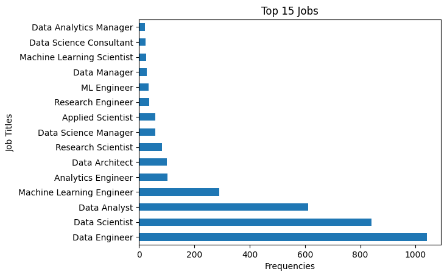

```python
top15jobs.plot(kind = 'barh')
plt.xlabel('Frequencies')
plt.ylabel('Job Titles')
plt.title('Top 15 Jobs')
```

Finding the jobs with highest salaries

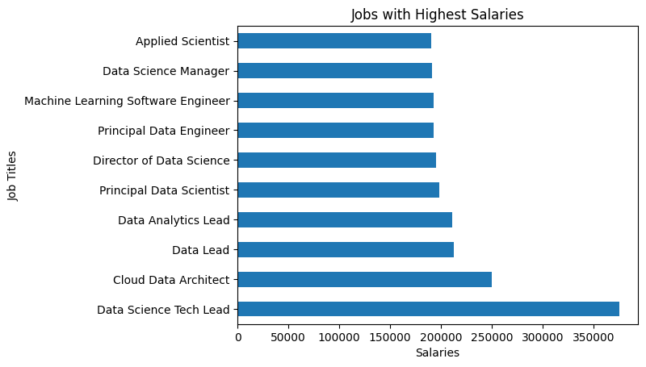

```python
highest_salary_jobs = dssalaries.groupby('job_title')['salary_in_usd'].mean().sort_values(ascending=False).head(10)
highest_salary_jobs.plot(kind = 'barh')
plt.xlabel('Salaries')
plt.ylabel('Job Titles')
plt.title('Jobs with Highest Salaries')
```

Finding salaries based on experience level

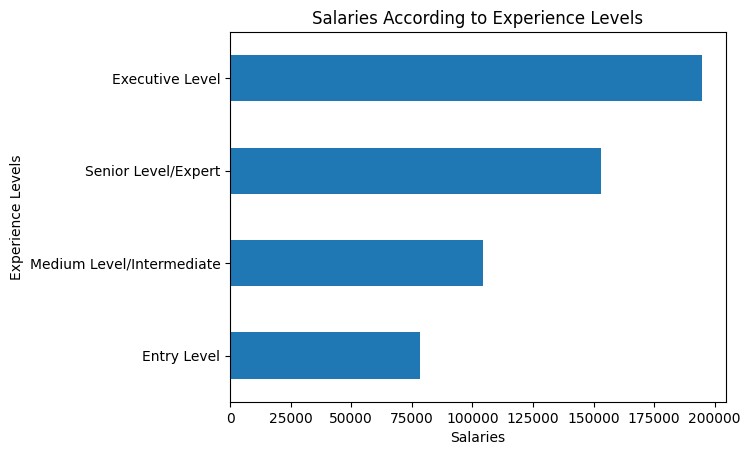

```python
exp_lvl_salaries = dssalaries.groupby('experience_level')['salary_in_usd'].mean().sort_values()
exp_lvl_salaries.plot(kind = 'barh')
plt.xlabel('Salaries')
plt.ylabel('Experience Levels')
plt.title('Salaries According to Experience Levels')
```

Showing the histogram of a column

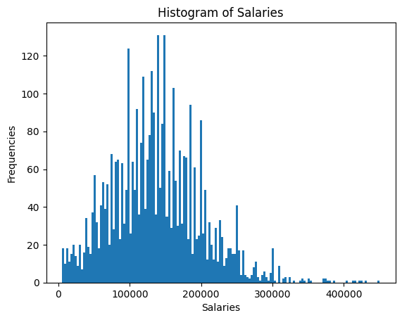

```python
histcol = 'salary_in_usd'
histvar = dssalaries[histcol]
histvar.plot(kind = 'hist', bins=150)
plt.xlabel('Salaries')
plt.ylabel('Frequencies')
plt.title('Histogram of Salaries')
```

Showing the box plot of a column

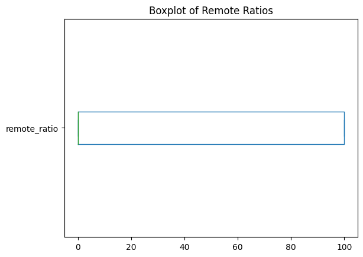

```python
boxcol = dssalaries['remote_ratio']
boxcol.plot(kind = 'box', vert=False)

plt.title('Boxplot of Remote Ratios')
```